# Worksheet 3 - Scientific Visualisation MVE080/MMG640

## Geospatial data

Name: *Houshi He*

1. It describes the tasks.
2. It (sometimes) provides coding templates that you can use as a basis for your own code.
3. It is a template also for the report that you upload in Canvas.

The tasks are of various types: some are to read some text and then comment on it (no coding), and some are about creating visualisations using plotnine. Once you're finished with all the tasks, export this document as an HTML file and upload it in Canvas. You are encouraged to discuss problems and solutions with your fellow students, but each student must solve all tasks by themselves and hand-in their own report. Notice that Jupyter notebooks use [Markdown](https://docs.github.com/en/github/writing-on-github/getting-started-with-writing-and-formatting-on-github/basic-writing-and-formatting-syntax#links) for writing text cells. Make sure you understand the basics.

The code below loads the packages required for this homework.

```python
import numpy as np
import pandas as pd
import geopandas as gpd
from plotnine import *
# Currently in a plotine dependancy they have deprication warning, so
# we mute warnings to have a better experience
import warnings
warnings.filterwarnings("ignore")

# A nice color palette for categorical data
cbPalette = ["#E69F00", "#56B4E9", "#009E73",
             "#F0E442", "#0072B2", "#D55E00",
             "#CC79A7", "#999999"]
```

## Task 1

Read Chapter 15 of [Fundamentals of Data Visualizations](https://clauswilke.com/dataviz/), then answer the questions below.

### Question 1.1

As the earth is not flat (and neither a [Möbius strip](https://en.wikipedia.org/wiki/M%C3%B6bius_strip)) when working with 2-dimensional maps we have to use a projection. Describe one scenario where it would not be suitable to use the Mercator's projection.

### Answer 1.1

*The Mercator projection keeps shapes and directions accurate but distorts size, making areas near the poles appear larger. It’s not suitable for comparing land areas of countries.*

### Question 1.2

A common form of visualisation for maps is the Choropleth map (e.g slide 15 lecture 5). Briefly discuss two important aspects to consider when creating a choropleth map.

### Answer 1.2

*A Choropleth map uses colors to show data on a map. It works best for visualizing densities, as a single value often doesn't represent an entire area. While we should be careful with the size of map areas, as large regions can dominate the viewer’s attention.*

### Question 1.3

Sometimes to avoid area problems, a more abstract map representation can be beneficial. Which abstract representation of Fig. 15.15 and Fig. 15.16 in the course book do you think work the best? Motivate!

### Answer 1.3

*I think Fig. 15.15 works better because it keeps the relationships clear. This makes it easier to focus on the data without being misled by size distortions caused by scaling.*

### Question 1.4

When creating a visual, what are three sources that often cause unwilling misleading?

### Answer 1.4

*Scaling and moving; projection; colored according to some quantity that is not a density*

## Geospatial data

For this part reading chapter 15 in [Fundamentals of Data Visualizations](https://clauswilke.com/dataviz/) can help. You need to have **geopandas** installed for this part (it should be installed if you have used the yml-file on the webpage).

### Question 2.1

Let us take a closer look at Starbucks. Produce two visuals where i) you use dots and ii) where you use colours (here you can represent countries without Starbucks as white) to show the number of Starbucks stores in different Asian countries.

*Hint - you can merge on iso_a3*

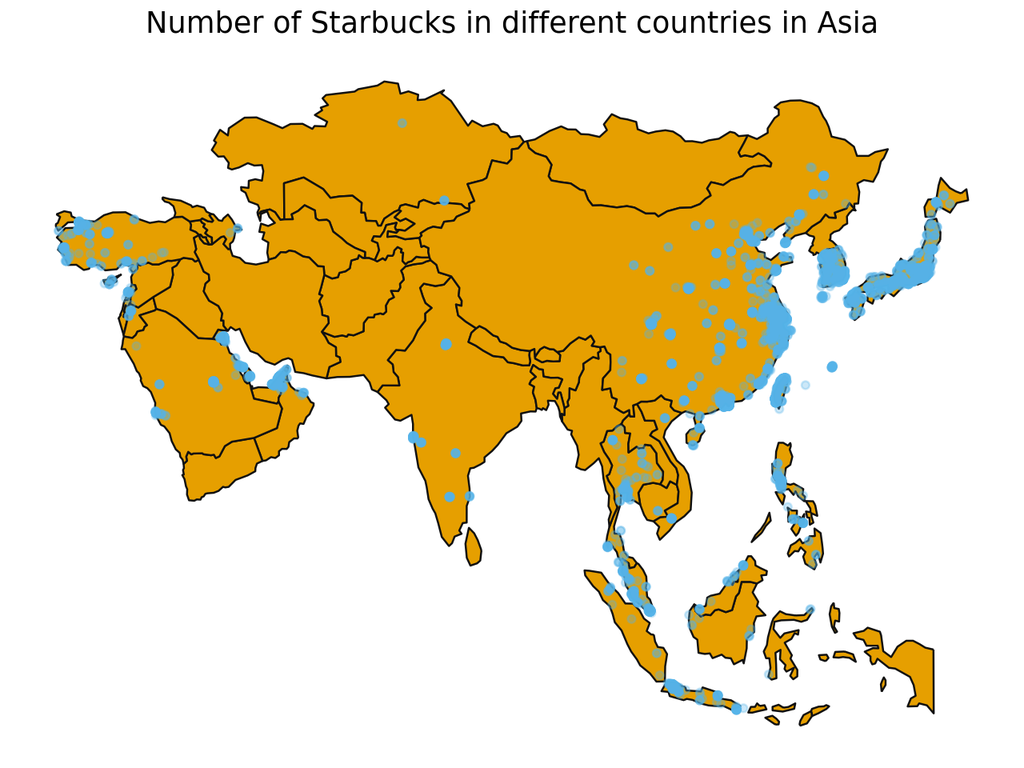

```python
# Insert code here for visual 1
# Load geographical data and filter for Asian countries
world = gpd.read_file(gpd.datasets.get_path("naturalearth_lowres"))
asia_map = world[world["continent"] == "Asia"]

# Load Starbucks data
starbucks_data = pd.read_csv('Starbucks_data-1.csv')

# Extract continent information from timezone and add a 'Continent' column
for i in range(starbucks_data.shape[0]):
    timezone = starbucks_data.loc[i, 'Timezone'].split('/')  # Split timezone string
    continent = timezone[0].split(' ')[-1]  # Extract the continent name
    starbucks_data.loc[i, 'Continent'] = continent

# Filter Starbucks data for Asia and remove outliers (Russia entries)
starbucks_asia = starbucks_data[starbucks_data['Continent'] == 'Asia']
starbucks_asia = starbucks_asia[starbucks_asia['iso_a3'] != 'RUS']

# Create the plot
plot = (
    ggplot()
    + geom_map(data=asia_map, fill=cbPalette[0])  # Map background
    + geom_point(  # Plot Starbucks locations
        data=starbucks_asia,
        mapping=aes(x='Longitude', y='Latitude'),
        color=cbPalette[1],
        alpha=0.3
    )
    + labs(x='', y='', title='Number of Starbucks in different countries in Asia')
    + theme(
        panel_background=element_rect(fill="white"),
        axis_ticks=element_blank(),
        axis_text=element_blank()
    )
)

# Display the plot
plot
# Remember to print the visual
```

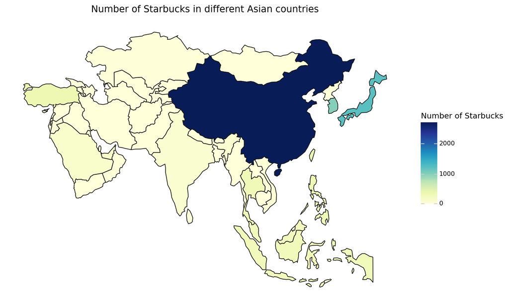

```python
# Insert code here for visual 2
# Load geographical data and filter for Asian countries
world = gpd.read_file(gpd.datasets.get_path("naturalearth_lowres"))
asia_map = world[world["continent"] == "Asia"]

# Load Starbucks data and calculate the number of stores per country
starbucks_data = pd.read_csv('Starbucks_data-1.csv')
store_counts = starbucks_data.groupby('iso_a3').size().reset_index(name='count')

# Merge Starbucks store count data with the Asia map
asia_map = asia_map.merge(store_counts, on='iso_a3', how='left')
asia_map['count'] = asia_map['count'].fillna(0)  # Replace NaN values with 0 for countries with no Starbucks

# Normalize the count column
asia_map['count_norm'] = (asia_map['count'] - asia_map['count'].mean()) / asia_map['count'].std()

# Create the plot
plot = (
    ggplot(asia_map)
    + geom_map(aes(geometry='geometry', fill='count'))
    + labs(x='', y='', title='Number of Starbucks in different Asian countries')
    + theme(
        panel_background=element_rect(fill="white"),
        axis_ticks=element_blank(),
        axis_text=element_blank(),
        figure_size=(10, 6)
    )
    + scale_fill_cmap('YlGnBu', name='Number of Starbucks')
)

# Display the plot
plot
# Remember to print the visual
```

## Question 2.2

On Canvas, I have uploaded two datasets with percentage of a countries surface that is covered by forests in 1990 and 2019. Create a visual which clearly shows how forest coverage has changed between 1990 and 2019.

Motivate choice of projection!

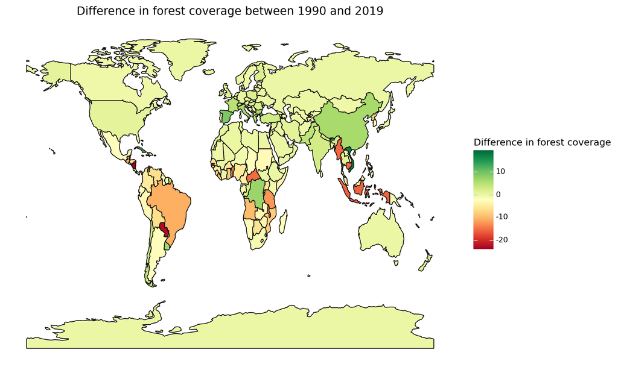

```python
# Insert code here for the visual
# Load geographical data and forest coverage data
world = gpd.read_file(gpd.datasets.get_path("naturalearth_lowres"))
forest_1990 = pd.read_csv('Forest_1990-1.csv')
forest_2019 = pd.read_csv('Forest_2019-1.csv')

# Calculate the difference in forest coverage between 2019 and 1990
forest_diff = pd.DataFrame({
    'Country': forest_2019['Country'],
    'diff': forest_2019['2019_forest'] - forest_1990['1990_forest']
})

# Merge the forest coverage difference with the world map
world = world.merge(forest_diff, left_on='name', right_on='Country', how='left')
world['diff'] = world['diff'].fillna(0)  # Replace NaN values with 0 for countries with no data

# Create the plot
plot = (
    ggplot(world)
    + geom_map(aes(geometry='geometry', fill='diff'))  # Fill countries based on forest coverage difference
    + scale_fill_cmap('RdYlGn', name='Difference in forest coverage')  # Use color map for the difference
    + theme(
        panel_background=element_rect(fill="white"),
        axis_ticks=element_blank(),
        axis_text=element_blank(),
        figure_size=(10, 6)  # Set the figure size
    )
    + labs(title='Difference in forest coverage between 1990 and 2019')
)

# Display the plot
plot
# Remember to print the visual
```

*Motivate choice of projection here*

*The default projection is used because it is simple and widely accepted for global maps. It shows locations accurately, making it easy to display general trends and comparisons across countries. However, it does distort shapes and sizes, especially at higher latitudes.*

## Question 2.3

On Canvas, I have uploaded a dataset of ILI activity level, a measure used to monitor the flu activity in the USA. Visualise the activity level in the USA using a choropleth visual with discrete binning of the different categories. Produce two visuals with different binning schemes, motivate which one you think works best for this data.

The code below helps you read the USA map.

```python
# Read USA map and filter away Alaska, Hawaii and non-mainland territories
'''
map_USA = gpd.read_file("path_USA_map")
map_USA = map_USA.loc[map_USA["STUSPS"] != "VI"]
map_USA = map_USA.loc[map_USA["STUSPS"] != "MP"]
map_USA = map_USA.loc[map_USA["STUSPS"] != "GU"]
map_USA = map_USA.loc[map_USA["STUSPS"] != "HI"]
map_USA = map_USA.loc[map_USA["STUSPS"] != "AK"]
map_USA = map_USA.loc[map_USA["STUSPS"] != "PR"]
'''
```

```
'\nmap_USA = gpd.read_file("path_USA_map")\nmap_USA = map_USA.loc[map_USA["STUSPS"] != "VI"]\nmap_USA = map_USA.loc[map_USA["STUSPS"] != "MP"]\nmap_USA = map_USA.loc[map_USA["STUSPS"] != "GU"]\nmap_USA = map_USA.loc[map_USA["STUSPS"] != "HI"]\nmap_USA = map_USA.loc[map_USA["STUSPS"] != "AK"]\nmap_US…
```

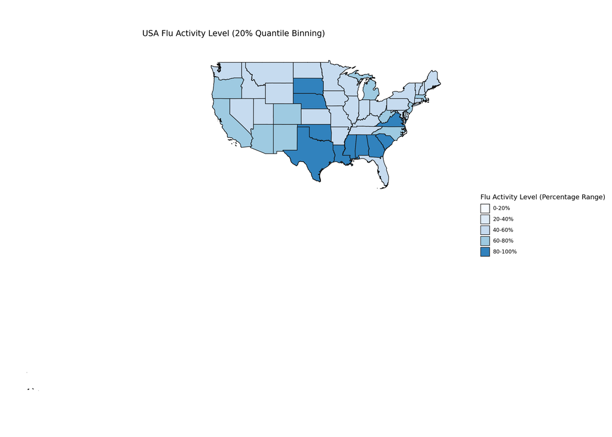

```python
# Insert code here for visual 1
# Read USA map and filter away Alaska, Hawaii, and non-mainland territories
map_USA = gpd.read_file("cb_2018_us_state_500k-2.zip")
map_USA = map_USA.loc[~map_USA["STUSPS"].isin(["VI", "MP", "GU", "HI", "AK", "PR"])]

# Read flu data
flu_data = pd.read_csv("Flu_data.csv")

# Merge the flu data with the map data based on state names
map_USA = map_USA.merge(flu_data, how="left", left_on="NAME", right_on="statename")

# Handle NaN and infinite values
map_USA['activity_level'] = map_USA['activity_level'].fillna(1)  # Fill NaN with 1 (or another suitable value)
map_USA['activity_level'] = map_USA['activity_level'].replace([np.inf, -np.inf], 1)  # Replace inf with 1 (or another suitable value)

# Ensure activity_level is between 1 and 10 and convert to integers
map_USA['activity_level'] = map_USA['activity_level'].clip(lower=1, upper=10).astype(int)

# ===============================
# 20% Quantile Binning (5 Categories)
# ===============================
# Calculate the percentiles for 20% bins
percentile_vals = np.percentile(map_USA['activity_level'], [0, 20, 40, 60, 80, 100])

# Create conditions based on percentiles for binning
conditions_percentile = [
    map_USA['activity_level'].lt(percentile_vals[1]),  # 0-20%
    (map_USA['activity_level'].ge(percentile_vals[1]) & map_USA['activity_level'].lt(percentile_vals[2])),  # 20-40%
    (map_USA['activity_level'].ge(percentile_vals[2]) & map_USA['activity_level'].lt(percentile_vals[3])),  # 40-60%
    (map_USA['activity_level'].ge(percentile_vals[3]) & map_USA['activity_level'].lt(percentile_vals[4])),  # 60-80%
    map_USA['activity_level'].ge(percentile_vals[4])  # 80-100%
]

# Define corresponding labels for each category (with percentage ranges)
choices_percentile = ["0-20%", "20-40%", "40-60%", "60-80%", "80-100%"]

# Assign categories based on conditions
map_USA['Flu_Level_Percentile'] = pd.Categorical(np.select(conditions_percentile, choices_percentile), categories=choices_percentile)

# Define colors for the percentile binning
col_use_percentile = ["#f7fbff", "#deebf7", "#c6dbef", "#9ecae1", "#3182bd"]

# Create choropleth map using percentile binning
plot1 = (
    ggplot(map_USA)
    + geom_map(aes(geometry='geometry', fill='Flu_Level_Percentile'))
    + scale_fill_manual(values=col_use_percentile, name='Flu Activity Level (Percentage Range)', labels=choices_percentile)  # Change title for better clarity
    + labs(title='USA Flu Activity Level (20% Quantile Binning)')
    + theme(
        panel_background=element_rect(fill="white"),
        axis_ticks=element_blank(),
        axis_text=element_blank(),
        figure_size=(14, 10)  # Increase the size of the figure to make the map larger
    )
    + coord_fixed(ratio=1.3)  # Adjust aspect ratio to make the map occupy more of the image space
)

# Display the percentile binning map
plot1

# Remember to print the visual
```

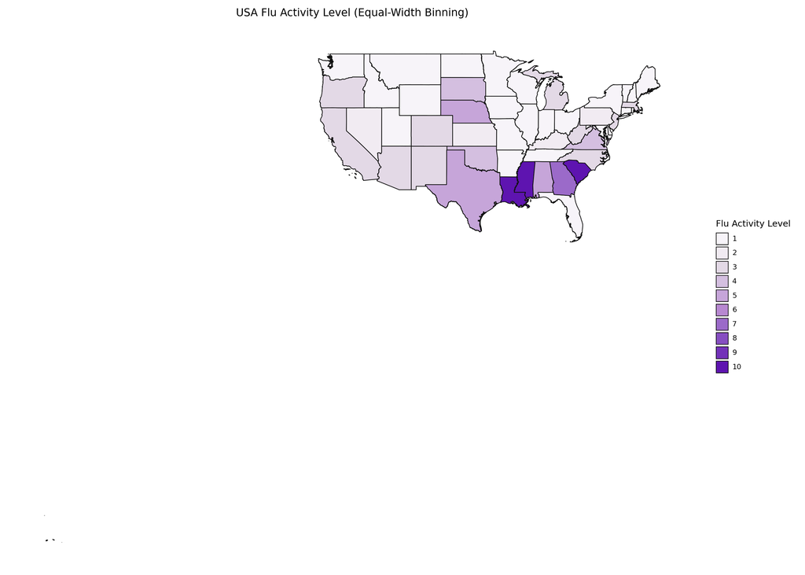

```python
# Insert code here for visual 2
# =================================
# Equal-Width Binning
# =================================
# Use equal-width binning
bins = np.linspace(1, 10, 11)  # Create 10 equal-width bins from 1 to 10
map_USA['Flu_Level_EqualWidth'] = pd.cut(map_USA['activity_level'], bins=bins, labels=choices_quantile, include_lowest=True)

# Define colors for equal-width binning
col_use_equal_width = ["#f7f4f9", "#f1ebf2", "#e3d9e6", "#d4bfe0", "#c6a5d9", "#b788d1", "#9b6ac9", "#864ec1", "#7331b9", "#5e14b0"]

# Create choropleth map using equal-width binning
plot2 = (
    ggplot(map_USA)
    + geom_map(aes(geometry='geometry', fill='Flu_Level_EqualWidth'))
    + scale_fill_manual(values=col_use_equal_width, name='Flu Activity Level')
    + labs(title='USA Flu Activity Level (Equal-Width Binning)')
    + theme(
        panel_background=element_rect(fill="white"),
        axis_ticks=element_blank(),
        axis_text=element_blank(),
        figure_size=(14, 10)
    )
    + coord_fixed(1.3)  # Ensure fixed aspect ratio
)

# Display the equal-width binning map
plot2
# Remember to print the visual
```

*Insert motivation*

*I think the second map works better because it uses 10 distinct levels, each represented by a unique color. This approach is not only clear and organized but also allows for easy comparison of each state's flu activity level relative to the rest of the country. The larger number of categories helps to capture more detail without overwhelming the viewer.*